# Data analysis V02

Loading packages First, the packages for the following analyses have to be loaded. At the same time, some adjustments to the output are made:

```r
# We load the helper-package pacman:
if (!require("pacman")) install.packages("pacman")
if (!require("devtools")) install.packages("devtools")
if (!require("tidystats")) install_github("willemsleegers/tidystats")
# So that we don't have to type install.packages("PACKAGENAME"); library(PACKAGENAME)
# for every single package. Instead, we can just type p_load() and
# provide a list of desired packages in parentheses:
pacman::p_load(tidyverse
       ,haven
       ,psych
       ,corx
       ,tableone
       ,nlme
       ,dplyr
       ,labelled
       ,lavaan
       ,lavaanPlot)
library(assertive, warn.conflicts = FALSE)
knitr::opts_chunk$set(message = FALSE,
                  warning = FALSE) # we don't want to see messages or warnings in the output
```

# Importing csv

```r
SPACE01_data_Masterarbeit <- read.csv2("SPACE01_data_Gabi.csv", na="NA")
```

# Data adjustment

## Sum of retention performance

```r
SPACE01_data_Masterarbeit$total_count <- SPACE01_data_Masterarbeit$recall_count + SPACE01_data_Masterarbeit$open.questions_count + SPACE01_data_Masterarbeit$transfer.questions_count
```

## Data exclusion

The following exclusion criteria are applied, based on a prior online data collection:  
1. Incomplete participation.  
2. Participated in the same study (participation_already).  
3. Used external resources (external.help_poststudy, external.help_spaced.poststudy2)  
4. Participants will be excluded from the final analyses, if they had a low recall performance (x i < M i – 2.5 *MAD) on the recall test in Learning Block 3 or at least the proportion of correctly recalled information being less than .1, with x i = n original observations, M = Median, MAD = Mean Absolute Deviation = b* M i (|x i – M j (xj )|), and b = 1.4826 AND fulfill one of the following conditions below (a-d):  
a. Participants are not fluent in German (i.e., they are not native in German, or moved to Germany or a German-speaking country before they were 16).  
b. Participants report to be either too distracted from their environment (disturbed_poststudy OR disturbed_poststudy1 OR disturbed_spaced.poststudy2 with 8 OR more on a 10-point Likert response scale) AND they could not sufficiently focus on the experiment (concentration_poststudy or concentration_poststudy1 or concentration_spaced.poststudy2 with 3 or less on a 10-point Likert response scale).  
c. Participants chose the items that they did not seriously participate and process the tasks in the study.  
d. Participants provide in the free comment box that they were not motivated or did not participate seriously.

Implementation

```r
library(dplyr)
# "participated in the same study"
# Remove rows by a column value
# df[!(df$cyl == 6),]

# 1. Incomplete participation: Closed out during the coding of the answers.

# 2. Participated in the same study (participation_already).
SPACE01_data_bereinigt02 <- SPACE01_data_Masterarbeit[!(SPACE01_data_Masterarbeit$participation_already == 'Ich habe schon einmal an DERSELBEN Studie teilgenommen.'),]

# 3. Used external resources (external.help_poststudy, external.help_spaced.poststudy2, )
SPACE01_data_bereinigt02 <- SPACE01_data_bereinigt02[!(SPACE01_data_bereinigt02$external.help_poststudy == 'Ja'),]
SPACE01_data_bereinigt02 <- SPACE01_data_bereinigt02[!(SPACE01_data_bereinigt02$external.help_spaced.poststudy2 == 'Ja'),]

# 4. Participants will be excluded from the final analyses, if they had a low or very high recall performance AND...
# calculating total "recall_performance" of each participant
## Sum of retention performance, new variable total_count to calculate limits for exclusion criteria
SPACE01_data_bereinigt02$total_count <- SPACE01_data_bereinigt02$recall_count + SPACE01_data_bereinigt02$open.questions_count + SPACE01_data_bereinigt02$transfer.questions_count

upper.limit <- median(SPACE01_data_bereinigt02$total_count) + 2.5*mad(SPACE01_data_bereinigt02$total_count)
lower.limit <- median(SPACE01_data_bereinigt02$total_count) - 2.5*mad(SPACE01_data_bereinigt02$total_count)
median(SPACE01_data_bereinigt02$total_count)
```

```
## [1] 9.75
```

```r
mad(SPACE01_data_bereinigt02$total_count)
```

```
## [1] 5.55975
```

```r
print(upper.limit)
```

```
## [1] 23.64937
```

```r
print(lower.limit)
```

```
## [1] -4.149375
```

```r
# because of the fact that the recall performance can't be negative only the upper limit has to be applied:
# 4.a eliminated by hand before
# 4.c eliminated by hand before
# 4.d eliminated by hand before
```

# Descriptive analyses

```r
psych::describe(SPACE01_data_bereinigt02$recall_count)
```

|  | vars | n | mean | sd | median | trimmed | mad | min | max | range | skew | kurtosis | se |
| --- | --- | --- | --- | --- | --- | --- | --- | --- | --- | --- | --- | --- | --- |
| X1 | 1 | 168 | 3.752976 | 2.570559 | 3.5 | 3.569853 | 2.9652 | 0 | 10.5 | 10.5 | 0.5116981 | -0.4728701 | 0.198323 |

```r
psych::describe(SPACE01_data_bereinigt02$open.questions_count)
```

|  | vars | n | mean | sd | median | trimmed | mad | min | max | range | skew | kurtosis | se |
| --- | --- | --- | --- | --- | --- | --- | --- | --- | --- | --- | --- | --- | --- |
| X1 | 1 | 168 | 2.232143 | 0.8492562 | 2 | 2.341912 | 1.4826 | 0 | 3 | 3 | -0.8938962 | -0.0179194 | 0.0655215 |

```r
psych::describe(SPACE01_data_bereinigt02$transfer.questions_count)
```

|  | vars | n | mean | sd | median | trimmed | mad | min | max | range | skew | kurtosis | se |
| --- | --- | --- | --- | --- | --- | --- | --- | --- | --- | --- | --- | --- | --- |
| X1 | 1 | 168 | 4.294643 | 2.917699 | 4 | 4.132353 | 3.33585 | 0 | 12.5 | 12.5 | 0.4438062 | -0.3016436 | 0.2251053 |

```r
psych::describe(SPACE01_data_bereinigt02$total_count)
```

|  | vars | n | mean | sd | median | trimmed | mad | min | max | range | skew | kurtosis | se |
| --- | --- | --- | --- | --- | --- | --- | --- | --- | --- | --- | --- | --- | --- |
| X1 | 1 | 168 | 10.27976 | 5.446721 | 9.75 | 10.11029 | 5.55975 | 0 | 24.5 | 24.5 | 0.2945293 | -0.4925595 | 0.4202237 |

```r
summary(SPACE01_data_bereinigt02)
```

```
##        ID               ID2          JSONversion        educational.attainment
##  Min.   :1838997   Min.   :1838997   Length:168         Length:168
##  1st Qu.:1883274   1st Qu.:1883274   Class :character   Class :character
##  Median :1948308   Median :1948308   Mode  :character   Mode  :character
##  Mean   :1963041   Mean   :1963041
##  3rd Qu.:2029808   3rd Qu.:2029808
##  Max.   :2167351   Max.   :2167351
##
##     gender            language          German.since        age
##  Length:168         Length:168         Min.   :19.00   Min.   :18.00
##  Class :character   Class :character   1st Qu.:22.00   1st Qu.:23.00
##  Mode  :character   Mode  :character   Median :25.00   Median :28.50
##                                        Mean   :25.79   Mean   :30.14
##                                        3rd Qu.:29.00   3rd Qu.:35.00
##                                        Max.   :39.00   Max.   :62.00
##                                        NA's   :154
##     multi             practice          recall_count    recall_accuracy
##  Length:168         Length:168         Min.   : 0.000   Min.   :0.0000
##  Class :character   Class :character   1st Qu.: 1.500   1st Qu.:0.1200
##  Mode  :character   Mode  :character   Median : 3.500   Median :0.2700
##                                        Mean   : 3.753   Mean   :0.2888
##                                        3rd Qu.: 5.500   3rd Qu.:0.4200
##                                        Max.   :10.500   Max.   :0.8100
##
##  open.questions_count open.questions_acc transfer.questions_count
##  Min.   :0.000        Min.   :0.0000     Min.   : 0.000
##  1st Qu.:2.000        1st Qu.:0.6700     1st Qu.: 2.000
##  Median :2.000        Median :0.6700     Median : 4.000
##  Mean   :2.232        Mean   :0.7446     Mean   : 4.295
##  3rd Qu.:3.000        3rd Qu.:1.0000     3rd Qu.: 6.500
##  Max.   :3.000        Max.   :1.0000     Max.   :12.500
##
##  PFT_overallAccuracy   interest_1     prior.knowledge_1 cognitive.effort_2
##  Length:168          Min.   :  0.00   Min.   : 0.00     Min.   :1.000
##  Class :character    1st Qu.: 40.00   1st Qu.: 5.00     1st Qu.:5.000
##  Mode  :character    Median : 68.00   Median :10.00     Median :6.000
##                      Mean   : 60.58   Mean   :17.58     Mean   :6.065
##                      3rd Qu.: 80.00   3rd Qu.:25.00     3rd Qu.:8.000
##                      Max.   :100.00   Max.   :90.00     Max.   :9.000
##
```

[output cut: 65 more lines]

```
##  Length:168                           Min.   : 0.000
##  Class :character                     1st Qu.: 4.000
##  Mode  :character                     Median : 7.000
##                                       Mean   : 6.318
##                                       3rd Qu.: 9.000
##                                       Max.   :10.000
##                                       NA's   :83
##  disturbed_spaced.poststudy2  total_count
##  Min.   : 0.000              Min.   : 0.00
##  1st Qu.: 0.000              1st Qu.: 6.50
##  Median : 1.000              Median : 9.75
##  Mean   : 2.271              Mean   :10.28
##  3rd Qu.: 4.000              3rd Qu.:14.00
##  Max.   :10.000              Max.   :24.50
##  NA's   :83
```

# Means of groups based on dependent variables (recall_count, open.questions_count, transfer.questions_count)

```r
#psych::describe(SPACE01_data_mono_massed$recall_count)
#psych::describe(SPACE01_data_mono_massed$open.questions_count)
#psych::describe(SPACE01_data_mono_massed$transfer.questions_count)

#psych::describe(SPACE01_data_mono_spaced$recall_count)
#psych::describe(SPACE01_data_mono_spaced$open.questions_count)
#psych::describe(SPACE01_data_mono_spaced$transfer.questions_count)

#psych::describe(SPACE01_data_multi_massed$recall_count)
#psych::describe(SPACE01_data_multi_massed$open.questions_count)
#psych::describe(SPACE01_data_multi_massed$transfer.questions_count)

#psych::describe(SPACE01_data_multi_spaced$recall_count)
#psych::describe(SPACE01_data_multi_spaced$open.questions_count)
#psych::describe(SPACE01_data_multi_spaced$transfer.questions_count)
```

# Boxplots, interaction plot

box plot with multiple groups +++++++++++++++++++++ plot total performance (“total_count”) by groups (“practice”) color box plot by a second group: “multi”

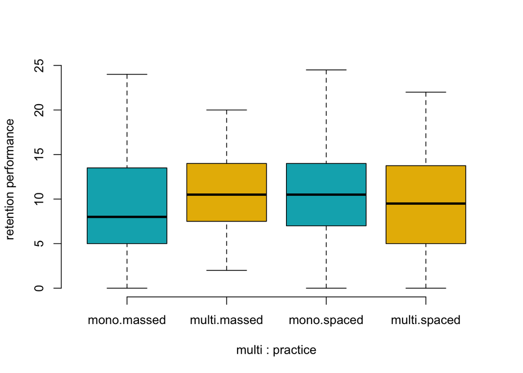

```r
# if(!require(devtools)) install.packages("devtools")
# devtools::install_github("kassambara/ggpubr")
# install.packages("ggpubr")
library("ggpubr")

# boxplot with two factor variables multi and practice
boxplot(total_count ~ multi * practice, data=SPACE01_data_bereinigt02, frame = FALSE,
        col = c("#00AFBB", "#E7B800"), ylab="retention performance")
```

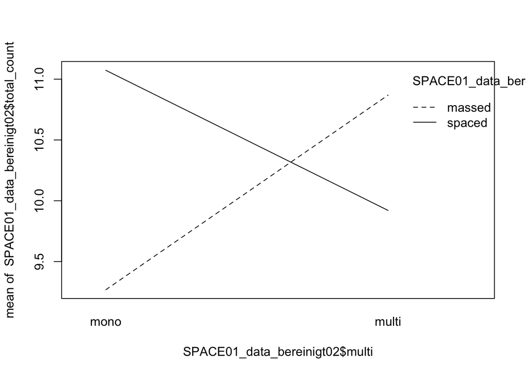

```r
interaction.plot(x.factor = SPACE01_data_bereinigt02$multi,
                 trace.factor = SPACE01_data_bereinigt02$practice,
                 response = SPACE01_data_bereinigt02$total_count)
```

```r
# boxplot(total_count ~ multi * practice, data=SPACE01_data_bereinigt02)

# model.tables(res.aov.total.interaction, type = "means")
# model.tables(res.aov.total.bereinigt.interaction, type = "means")
```

Crossing lines —> antagonistic interaction effect.

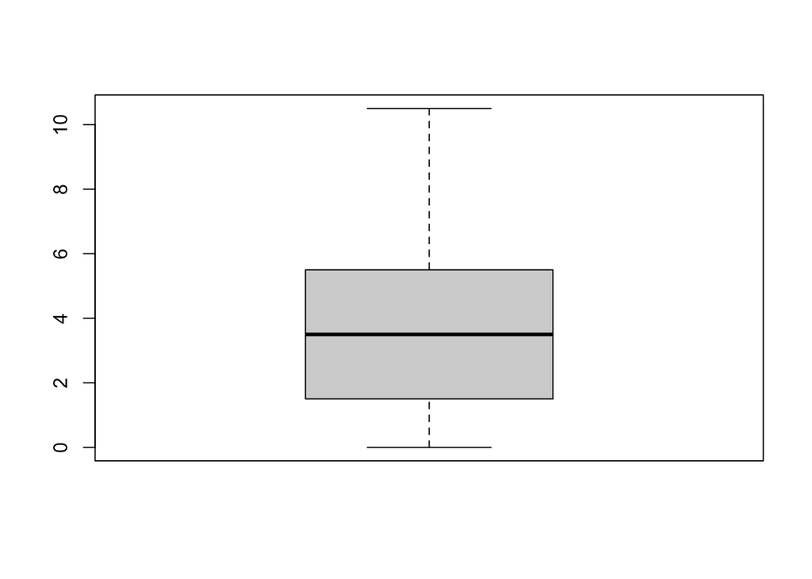

```r
  boxplot(SPACE01_data_bereinigt02$recall_count) +
  geom_boxplot() +
  theme_bw()
```

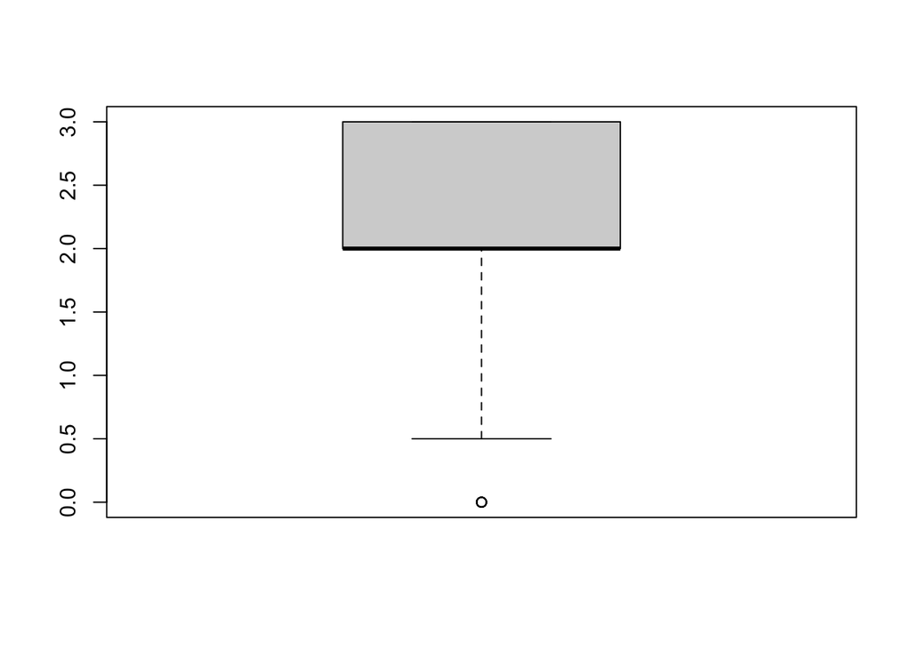

```r
  boxplot(SPACE01_data_bereinigt02$open.questions_count) +
  geom_boxplot() +
  theme_bw()
```

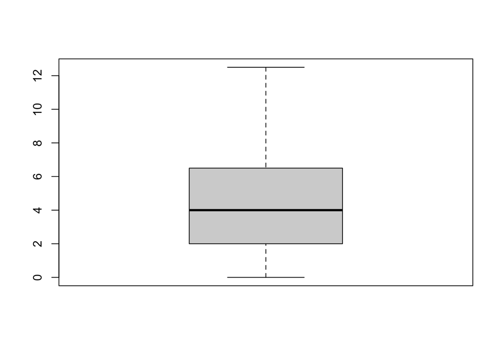

```r
    boxplot(SPACE01_data_bereinigt02$transfer.questions_count) +
  geom_boxplot() +
  theme_bw()
```

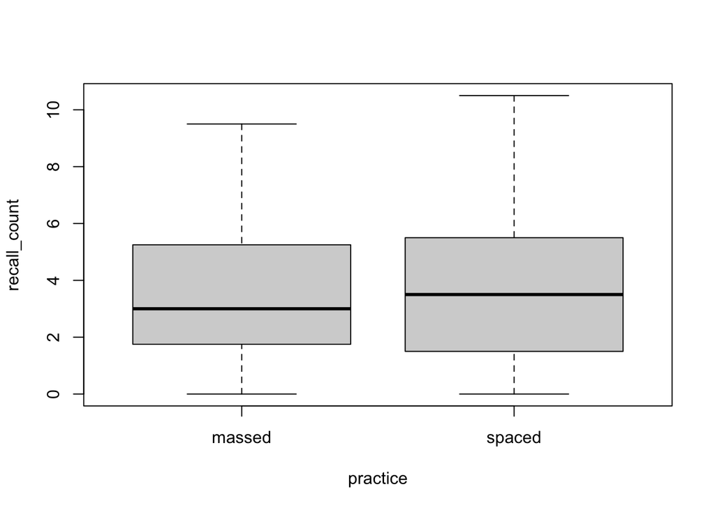

```r
attach(SPACE01_data_bereinigt02)
boxplot(recall_count~practice)
```

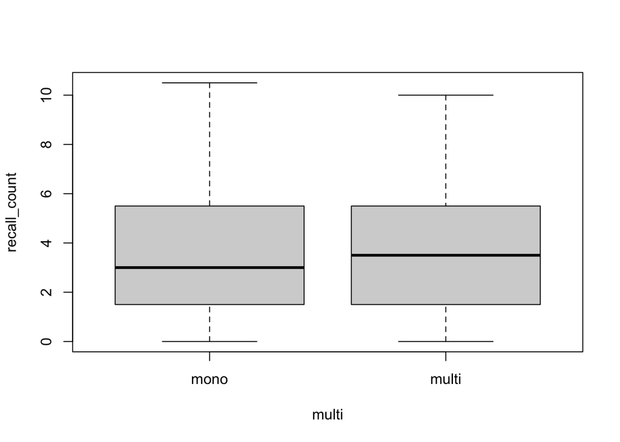

```r
boxplot(recall_count~multi)
```

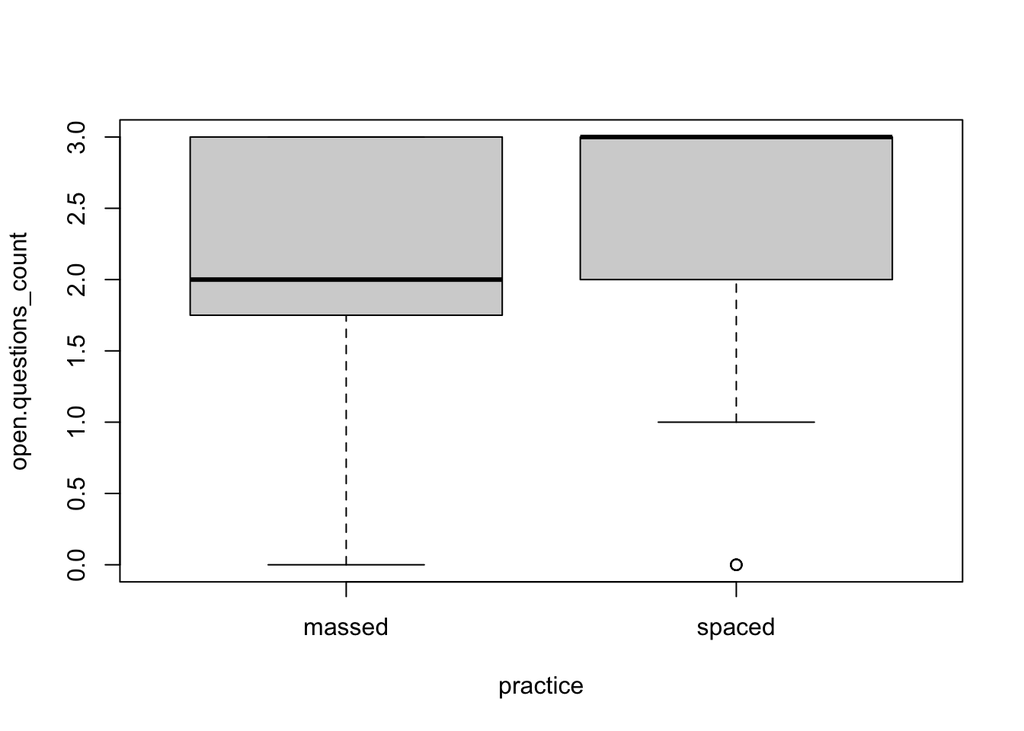

```r
boxplot(open.questions_count~practice)
```

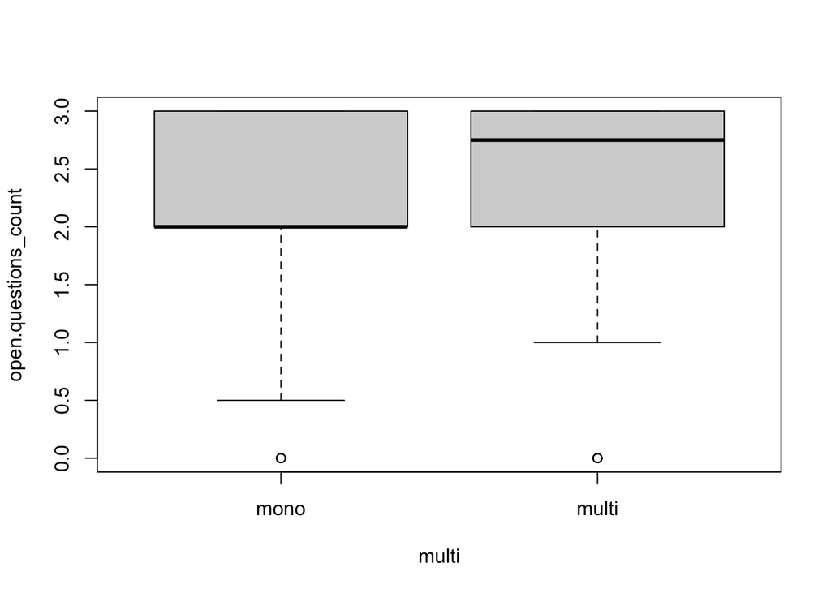

```r
boxplot(open.questions_count~multi)
```

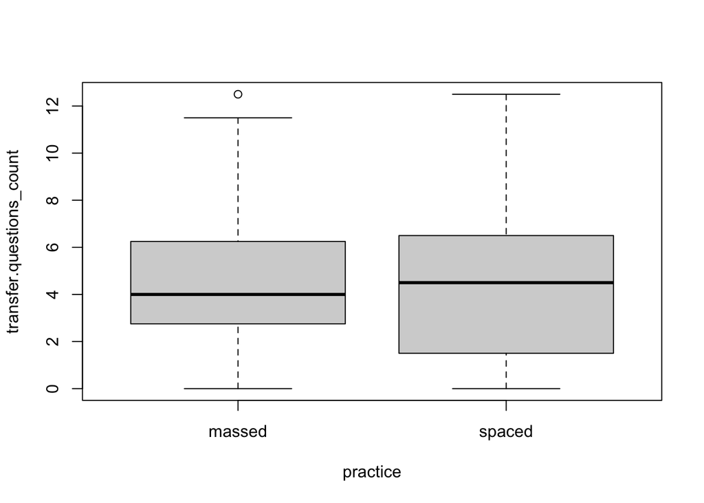

```r
boxplot(transfer.questions_count~practice)
```

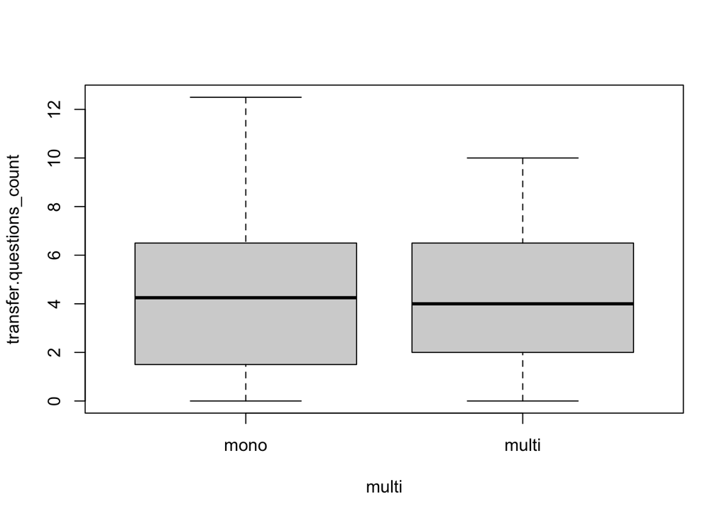

```r
boxplot(transfer.questions_count~multi)
```

```r
detach(SPACE01_data_bereinigt02)
```

# Compute mean and SD by groups

```r
require("dplyr")
# free recall
group_by(SPACE01_data_bereinigt02, multi, practice) %>%
  summarise(
    mean = mean(recall_count, na.rm = TRUE),
    sd = sd(recall_count, na.rm = TRUE)
  )
```

| multi | practice | mean | sd |
| --- | --- | --- | --- |
| mono | massed | 3.170732 | 2.551004 |
| mono | spaced | 4.097561 | 2.515501 |
| multi | massed | 4.154762 | 2.264487 |
| multi | spaced | 3.590909 | 2.865741 |

```r
# open.questions_recall
group_by(SPACE01_data_bereinigt02, multi, practice) %>%
  summarise(
    mean = mean(open.questions_count, na.rm = TRUE),
    sd = sd(open.questions_count, na.rm = TRUE)
  )
```

| multi | practice | mean | sd |
| --- | --- | --- | --- |
| mono | massed | 1.963415 | 0.9040896 |
| mono | spaced | 2.365854 | 0.7333518 |
| multi | massed | 2.261905 | 0.8057574 |
| multi | spaced | 2.329546 | 0.9082515 |

```r
# transfer.questions_recall
group_by(SPACE01_data_bereinigt02, multi, practice) %>%
  summarise(
    mean = mean(transfer.questions_count, na.rm = TRUE),
    sd = sd(transfer.questions_count, na.rm = TRUE)
  )
```

| multi | practice | mean | sd |
| --- | --- | --- | --- |
| mono | massed | 4.134146 | 3.150445 |
| mono | spaced | 4.609756 | 3.165265 |
| multi | massed | 4.452381 | 2.334287 |
| multi | spaced | 4.000000 | 3.013535 |

# Lambdas recall

# Lambdas open.questions

1. Calculating means:  
   recall_count  
   • moma: 1.96  
   • mospa: 2.37  
   • muma: 2.26  
   • muspa: 2.33
2. Overall mean:  
   • (1.96 + 2.37 + 2.26 + 2.33) / 4 = 2.23
3. Calculating Lambdas:  
   • moma: 1.96 - 2.23 = -0.27  
   • mospa: 2.37 - 2.23 = 0.14  
   • muma: 2.26 - 2.23 = 0.03  
   • muspa: 2.33 - 2.23 = 0.1
4. Testing if sum is 0:  
   • -0.27 + 0.14 + 0.03 + 0.1 = 0

# Lambdas transfer.questions

1. Calculating means:  
   recall_count  
   • moma: 4.13  
   • mospa: 4.61  
   • muma: 4.45  
   • muspa: 4.0
2. Overall mean:  
   • (4.13 + 4.61 + 4.45 + 4.0) / 4 = 4.2975
3. Calculating Lambdas:  
   • moma: 4.13 - 4.2975 = -0.1675  
   • mospa: 4.61 - 4.2975 = 0.3125  
   • muma: 4.45 - 4.2975 = 0.1525  
   • muspa: 4.0 - 4.2975 = -0.2975
4. Testing if sum is 0:  
   • -0.1675 + 0.3125 + 0.1525 + (-0.2975) = 0

# Contrasts for Hypotheses

Hypothesis 1 Spacing effect:  
Hypothesis 1.1: Spacing leads to a higher recall performance after 1 week compared to massed learning of monomedia texts.  
Hypothesis 1.2: Spacing leads to a similar recall performance after 1 week compared to massed learning of monomedia texts.

Hypothesis 2 Multimedia effect:  
Hypothesis 1.1: Learning with multimedia material leads to a higher recall performance after 1 week than learning with monomedia text in the massed learning group.  
Hypothesis 1.2: Learning with multimedia material leads to a similar recall performance after 1 week than learning with monomedia text in the massed learning group.

```r
# effects only
res.aov.total <- aov(total_count ~ practice + multi, data = SPACE01_data_bereinigt02)
summary(res.aov.total)
```

```
##              Df Sum Sq Mean Sq F value Pr(>F)
## practice      1      7   6.657   0.222  0.638
## multi         1      2   1.823   0.061  0.806
## Residuals   165   4946  29.975
```

```r
# with interaction
res.aov.total.interaction <- aov(total_count ~ practice * multi, data = SPACE01_data_bereinigt02)
summary(res.aov.total.interaction)
```

```
##                 Df Sum Sq Mean Sq F value Pr(>F)
## practice         1      7    6.66   0.224  0.636
## multi            1      2    1.82   0.061  0.805
## practice:multi   1     80   79.54   2.681  0.103
## Residuals      164   4866   29.67
```

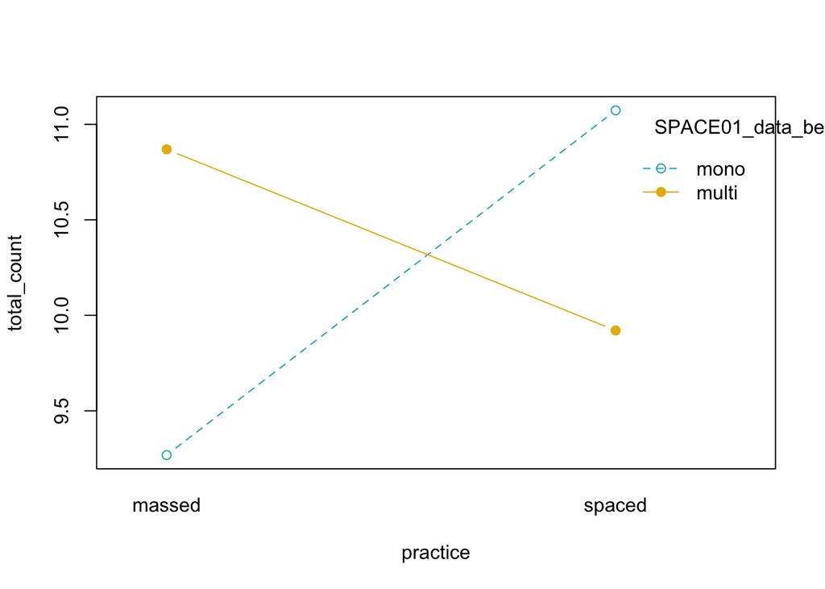

```r
# two-way interaction plot
interaction.plot(x.factor = SPACE01_data_bereinigt02$practice, trace.factor = SPACE01_data_bereinigt02$multi,
                 response = SPACE01_data_bereinigt02$total_count, fun = mean,
                 type = "b", legend = TRUE,
                 xlab = "practice", ylab="total_count",
                 pch=c(1,19), col = c("#00AFBB", "#E7B800"))
```

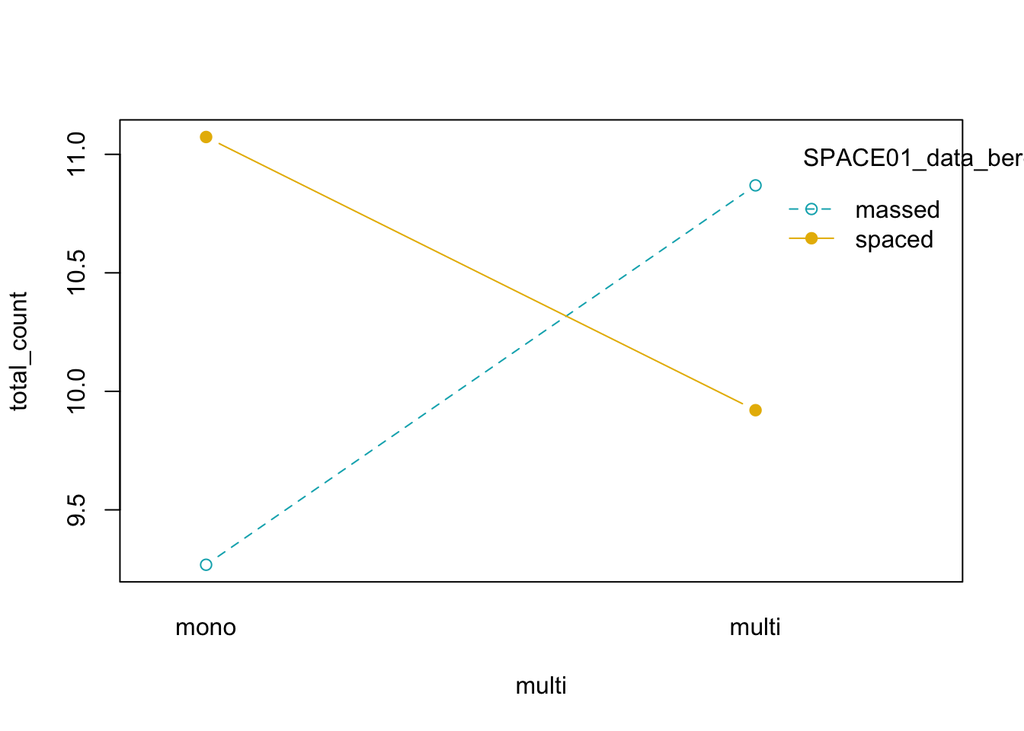

```r
interaction.plot(x.factor = SPACE01_data_bereinigt02$multi, trace.factor = SPACE01_data_bereinigt02$practice,
                 response = SPACE01_data_bereinigt02$total_count, fun = mean,
                 type = "b", legend = TRUE,
                 xlab = "multi", ylab="total_count",
                 pch=c(1,19), col = c("#00AFBB", "#E7B800"))
```

Cross-over interaction. Maybe an antagonistic interaction.

Datasets for every group

```r
SPACE01_data_mono <- SPACE01_data_bereinigt02[SPACE01_data_bereinigt02$multi == "mono",]
SPACE01_data_multi <- SPACE01_data_bereinigt02[SPACE01_data_bereinigt02$multi == "multi",]
SPACE01_data_massed <- SPACE01_data_bereinigt02[SPACE01_data_bereinigt02$practice == "massed",]
SPACE01_data_mono_massed <- SPACE01_data_mono[SPACE01_data_mono$practice == "massed",]
SPACE01_data_mono_spaced <- SPACE01_data_mono[SPACE01_data_mono$practice == "spaced",]
SPACE01_data_multi_massed <- SPACE01_data_multi[SPACE01_data_multi$practice == "massed",]
SPACE01_data_multi_spaced <- SPACE01_data_multi[SPACE01_data_multi$practice == "spaced",]
```

```r
# practice und multi als Faktoren deklarieren
SPACE01_data_multi$practice <- as.factor(SPACE01_data_multi$practice)
SPACE01_data_multi$multi <- as.factor(SPACE01_data_multi$multi)
SPACE01_data_mono$practice <- as.factor(SPACE01_data_mono$practice)
SPACE01_data_mono$multi <- as.factor(SPACE01_data_mono$multi)
SPACE01_data_massed$practice <- as.factor(SPACE01_data_massed$practice)
SPACE01_data_massed$multi <- as.factor(SPACE01_data_massed$multi)
```

## Contrast analysis Hypothesis 1

Hypothesis 1 Spacing effect:  
Hypothesis 1.1: Spacing leads to a higher recall performance after 1 week compared to massed learning of monomedia texts.  
Hypothesis 1.2: Spacing leads to a similar recall performance after 1 week compared to massed learning of monomedia texts.

### Hypothesis 1.1 recall

Lambda  
• moma: -0.66  
• mospa: 0.31

```r
library(cofad)
contrast_spacing_recall <- calc_contrast(
  dv=recall_count,
  between= practice,
  lambda_between = c("massed" = -0.66, "spaced" = 0.31),
  data = SPACE01_data_mono
)
summary(contrast_spacing_recall)
```

```
## $`F-Table`
##               SS df     MS     F     p
## contrast  17.610  1 17.610 2.744 0.102
## within   513.415 80  6.418    NA    NA
## total    531.024 81     NA    NA    NA
##
## $Effects
##              effects
## r_effectsize   0.182
## r_contrast     0.182
## r_alerting     1.000
```

### Hypothesis 1.1 open.questions

Lambda  
• moma: -0.27  
• mospa: 0.14

```r
library(cofad)
contrast_spacing_openq <- calc_contrast(
  dv=open.questions_count,
  between= practice,
  lambda_between = c("massed" = -0.27, "spaced" = 0.14),
  data = SPACE01_data_mono
)
summary(contrast_spacing_openq)
```

```
## $`F-Table`
##              SS df    MS   F    p
## contrast  3.320  1 3.320 4.9 0.03
## within   54.207 80 0.678  NA   NA
## total    57.527 81    NA  NA   NA
##
## $Effects
##              effects
## r_effectsize    0.24
## r_contrast      0.24
## r_alerting      1.00
```

Significant outcome p = 0.0297063 open.questions mospa gegen moma –> spacing effect.

### Hypothesis 1.1 transfer.questions

Lambda  
• moma: -0.1675  
• mospa: 0.3125

```r
library(cofad)
contrast_spacing_transferq <- calc_contrast(
  dv=transfer.questions_count,
  between= practice,
  lambda_between = c("massed" = -0.1675, "spaced" = 0.3125),
  data = SPACE01_data_mono
)
summary(contrast_spacing_transferq)
```

```
## $`F-Table`
##               SS df    MS     F     p
## contrast   4.637  1 4.637 0.465 0.497
## within   797.768 80 9.972    NA    NA
## total    802.405 81    NA    NA    NA
##
## $Effects
##              effects
## r_effectsize   0.076
## r_contrast     0.076
## r_alerting     1.000
```

## Contrast analysis Hypothesis 2

Hypothesis 2 Multimedia effect:  
Hypothesis 2.1: Learning with multimedia material leads to a higher recall performance after 1 week than learning with monomedia text in the massed learning group.  
Hypothesis 2.2: Learning with multimedia material leads to a similar recall performance after 1 week than learning with monomedia text in the massed learning group.

### Hypothesis 2.1 recall

Lambda  
• moma: -0.66  
• muma: 0.55

```r
library(cofad)
contrast_multimedia_recall <- calc_contrast(
  dv=recall_count,
  between= multi,
  lambda_between = c("mono" = -0.66, "multi" = 0.55),
  data = SPACE01_data_massed
)
summary(contrast_multimedia_recall)
```

```
## $`F-Table`
##               SS df     MS     F     p
## contrast  20.090  1 20.090 3.453 0.067
## within   471.239 81  5.818    NA    NA
## total    490.639 82     NA    NA    NA
##
## $Effects
##              effects
## r_effectsize   0.202
## r_contrast     0.202
## r_alerting     1.000
```

### Hypothesis 2.1 open.questions

Lambda  
• moma: -0.27  
• muma: 0.03

```r
library(cofad)
contrast_multimedia_openq <- calc_contrast(
  dv=open.questions_count,
  between= multi,
  lambda_between = c("mono" = -0.27, "multi" = 0.03),
  data = SPACE01_data_massed
)
summary(contrast_multimedia_openq)
```

```
## $`F-Table`
##              SS df    MS     F     p
## contrast  1.848  1 1.848 2.521 0.116
## within   59.398 81 0.733    NA    NA
## total    61.163 82    NA    NA    NA
##
## $Effects
##              effects
## r_effectsize   0.174
## r_contrast     0.174
## r_alerting     1.000
```

### Hypothesis 2.1 transfer.questions

Lambda  
• moma: -0.1675  
• muma: 0.1525

```r
library(cofad)
contrast_multimedia_transferq <- calc_contrast(
  dv=transfer.questions_count,
  between= multi,
  lambda_between = c("mono" = -0.1675, "multi" = 0.1525),
  data = SPACE01_data_massed
)
summary(contrast_multimedia_transferq)
```

```
## $`F-Table`
##               SS df    MS     F     p
## contrast   2.101  1 2.101 0.273 0.603
## within   622.655 81 7.687    NA    NA
## total    622.518 82    NA    NA    NA
##
## $Effects
##              effects
## r_effectsize   0.058
## r_contrast     0.058
## r_alerting     1.000
```

## Contrast analysis Hypothesis 3

Hypothesis 3 Antagonistic interaction of spacing and multimedia effect:  
Hypothesis 3: Combining spacing and multimedia material leads to lower retention performance.  
Contrasts (explicit for every dv):  
muspa < muma  
muspa < mospa  
### Hypothesis 3 recall Lambda  
• muma: 0.55  
• muspa: -0.20

```r
library(cofad)
SPACE01_data_bereinigt02$practice <- as.factor(SPACE01_data_bereinigt02$practice)
SPACE01_data_bereinigt02$multi <- as.factor(SPACE01_data_bereinigt02$multi)

contrast_antagonist_effect_recall <- calc_contrast(
  dv=recall_count,
  between= practice,
  lambda_between=c("spaced"=-0.2, "massed"=0.55),
  data=SPACE01_data_multi
)
summary(contrast_antagonist_effect_recall)
```

```
## $`F-Table`
##               SS df    MS     F     p
## contrast   6.832  1 6.832 1.024 0.314
## within   560.296 84 6.670    NA    NA
## total    570.212 85    NA    NA    NA
##
## $Effects
##              effects
## r_effectsize   0.109
## r_contrast     0.109
## r_alerting     1.000
```

### Hypothesis 3 open.questions

Lambda  
• muma: 0.03  
• muspa: 0.1

```r
calc_contrast(
  dv=open.questions_count,
  between= practice,
  lambda_between=c("spaced"=0.1, "massed"=0.03),
  data=SPACE01_data_multi
)
```

```
##
## Contrast Analysis for between factor design
##
## F(1,84) = 0.133; p = 0.71586701
## Contrasts:  massed = -0.035; spaced = 0.035
## r_effectsize = 0.04
```

### Hypothesis 3 transfer.questions

Lambda  
• muma: 0.1525  
• muspa: -0.2975

```r
calc_contrast(
  dv=transfer.questions_count,
  between= practice,
  lambda_between=c("spaced"=-0.2975, "massed"=0.1525),
  data=SPACE01_data_multi
)
```

```
##
## Contrast Analysis for between factor design
##
## F(1,84) = 0.605; p = 0.43875038
## Contrasts:  massed = 0.225; spaced = -0.225
## r_effectsize = 0.084
```

# Significant contrasts:

Significant outcome with p = 0.0297063 - for open.questions mospa vs. moma –> spacing effect.

# Contrasts for antagonistic interaction:

```r
library(cofad)

contrast_antagonist_effect_recall <- calc_contrast(
  dv=recall_count,
  between= practice,
  lambda_between=c("spaced"=-0.2, "massed"=0.55),
  data=SPACE01_data_multi
)
summary(contrast_antagonist_effect_recall)
```

```
## $`F-Table`
##               SS df    MS     F     p
## contrast   6.832  1 6.832 1.024 0.314
## within   560.296 84 6.670    NA    NA
## total    570.212 85    NA    NA    NA
##
## $Effects
##              effects
## r_effectsize   0.109
## r_contrast     0.109
## r_alerting     1.000
```

# t-Tests

## recall_count

Freier Abruf, DV recall_count

### mono-massed/mono-spaced

Bezugswert ist die mono-massed Gruppe mit einem Mittelwert von 3.171 für recall_count (freier Abruf von erinnertem Wissen)  
Dagegen wird die Gruppe mono-spaced getestet.

```r
t.test(SPACE01_data_mono_spaced$recall_count, mu=3.171, alternative = "greater")
```

```
##
##  One Sample t-test
##
## data:  SPACE01_data_mono_spaced$recall_count
## t = 2.3585, df = 40, p-value = 0.01166
## alternative hypothesis: true mean is greater than 3.171
## 95 percent confidence interval:
##  3.436051      Inf
## sample estimates:
## mean of x
##  4.097561
```

### mono-massed/multi-massed

Bezugswert ist die mono-massed Gruppe mit einem Mittelwert von 3.171 für recall_count. Dagegen wird die Gruppe multi-massed getestet.

```r
t.test(SPACE01_data_multi_massed$recall_count, mu=3.171, alternative = "greater")
```

```
##
##  One Sample t-test
##
## data:  SPACE01_data_multi_massed$recall_count
## t = 2.8154, df = 41, p-value = 0.003727
## alternative hypothesis: true mean is greater than 3.171
## 95 percent confidence interval:
##  3.566734      Inf
## sample estimates:
## mean of x
##  4.154762
```

### multi-spaced

Bezugswert ist die mono-massed Gruppe mit einem Mittelwert von 3.171 für recall_count.  
Dagegen werden alle 3 anderen Gruppen getestet.

```r
t.test(SPACE01_data_multi_spaced$recall_count, mu=3.171, alternative = "greater") # multi-spaced gegen mono-massed
```

```
##
##  One Sample t-test
##
## data:  SPACE01_data_multi_spaced$recall_count
## t = 0.97195, df = 43, p-value = 0.1683
## alternative hypothesis: true mean is greater than 3.171
## 95 percent confidence interval:
##  2.864642      Inf
## sample estimates:
## mean of x
##  3.590909
```

```r
t.test(SPACE01_data_multi_spaced$recall_count, mu=4.098, alternative = "greater") # gegen mono-spaced
```

```
##
##  One Sample t-test
##
## data:  SPACE01_data_multi_spaced$recall_count
## t = -1.1737, df = 43, p-value = 0.8765
## alternative hypothesis: true mean is greater than 4.098
## 95 percent confidence interval:
##  2.864642      Inf
## sample estimates:
## mean of x
##  3.590909
```

```r
t.test(SPACE01_data_multi_spaced$recall_count, mu=4.155, alternative = "greater") # gegen multi-massed
```

```
##
##  One Sample t-test
##
## data:  SPACE01_data_multi_spaced$recall_count
## t = -1.3057, df = 43, p-value = 0.9007
## alternative hypothesis: true mean is greater than 4.155
## 95 percent confidence interval:
##  2.864642      Inf
## sample estimates:
## mean of x
##  3.590909
```

## open.questions_count

Freier Abruf, DV open.questions_count ### mono-massed/mono-spaced Bezugswert ist die mono-massed Gruppe mit einem Mittelwert von 1.963 für open.questions_count (offene Fragen)  
Dagegen wird die Gruppe mono-spaced getestet.

```r
t.test(SPACE01_data_mono_spaced$open.questions_count, mu=1.963, alternative = "greater")
```

```
##
##  One Sample t-test
##
## data:  SPACE01_data_mono_spaced$open.questions_count
## t = 3.5174, df = 40, p-value = 0.0005506
## alternative hypothesis: true mean is greater than 1.963
## 95 percent confidence interval:
##  2.173002      Inf
## sample estimates:
## mean of x
##  2.365854
```

### mono-massed/multi-massed

Bezugswert ist die mono-massed Gruppe mit einem Mittelwert von 1.963 für open.questions_count.  
Dagegen wird die Gruppe multi-massed getestet.

```r
t.test(SPACE01_data_multi_massed$open.questions_count, mu=1.963, alternative = "greater")
```

```
##
##  One Sample t-test
##
## data:  SPACE01_data_multi_massed$open.questions_count
## t = 2.4041, df = 41, p-value = 0.01041
## alternative hypothesis: true mean is greater than 1.963
## 95 percent confidence interval:
##  2.052671      Inf
## sample estimates:
## mean of x
##  2.261905
```

### multi-spaced

Bezugswert ist die mono-massed Gruppe mit einem Mittelwert von 1.963 für open.questions_count. Dagegen werden alle 3 anderen Gruppen getestet.

```r
t.test(SPACE01_data_multi_spaced$open.questions_count, mu=1.963, alternative = "greater") # multi-spaced gegen mono-massed
```

```
##
##  One Sample t-test
##
## data:  SPACE01_data_multi_spaced$open.questions_count
## t = 2.677, df = 43, p-value = 0.005237
## alternative hypothesis: true mean is greater than 1.963
## 95 percent confidence interval:
##  2.099366      Inf
## sample estimates:
## mean of x
##  2.329545
```

```r
t.test(SPACE01_data_multi_spaced$open.questions_count, mu=2.366, alternative = "greater") # gegen mono-spaced
```

```
##
##  One Sample t-test
##
## data:  SPACE01_data_multi_spaced$open.questions_count
## t = -0.26624, df = 43, p-value = 0.6043
## alternative hypothesis: true mean is greater than 2.366
## 95 percent confidence interval:
##  2.099366      Inf
## sample estimates:
## mean of x
##  2.329545
```

```r
t.test(SPACE01_data_multi_spaced$open.questions_count, mu=2.262, alternative = "greater") # gegen multi-massed
```

```
##
##  One Sample t-test
##
## data:  SPACE01_data_multi_spaced$open.questions_count
## t = 0.49331, df = 43, p-value = 0.3122
## alternative hypothesis: true mean is greater than 2.262
## 95 percent confidence interval:
##  2.099366      Inf
## sample estimates:
## mean of x
##  2.329545
```

## transfer.questions_count

Freier Abruf, DV transfer.questions_count  
### mono-massed/mono-spaced Bezugswert ist die mono-massed Gruppe mit einem Mittelwert von 4.134 für transfer.questions_count (Transferfragen als MC)  
Dagegen wird die Gruppe mono-spaced getestet.

```r
t.test(SPACE01_data_mono_spaced$transfer.questions_count, mu=4.134, alternative = "greater")
```

```
##
##  One Sample t-test
##
## data:  SPACE01_data_mono_spaced$transfer.questions_count
## t = 0.96242, df = 40, p-value = 0.1708
## alternative hypothesis: true mean is greater than 4.134
## 95 percent confidence interval:
##  3.777376      Inf
## sample estimates:
## mean of x
##  4.609756
```

### mono-massed/multi-massed

```r
t.test(SPACE01_data_multi_massed$transfer.questions_count, mu=4.134, alternative = "greater")
```

```
##
##  One Sample t-test
##
## data:  SPACE01_data_multi_massed$transfer.questions_count
## t = 0.88393, df = 41, p-value = 0.1909
## alternative hypothesis: true mean is greater than 4.134
## 95 percent confidence interval:
##  3.846228      Inf
## sample estimates:
## mean of x
##  4.452381
```

### multi-spaced

Bezugswert ist die mono-massed Gruppe mit einem Mittelwert von 4.134 für transfer.questions_count. Dagengen werden alle 3 anderen Gruppen getestet.

```r
t.test(SPACE01_data_multi_spaced$transfer.questions_count, mu=4.134, alternative = "greater") # multi-spaced gegen mono-massed
```

```
##
##  One Sample t-test
##
## data:  SPACE01_data_multi_spaced$transfer.questions_count
## t = -0.29495, df = 43, p-value = 0.6153
## alternative hypothesis: true mean is greater than 4.134
## 95 percent confidence interval:
##  3.236277      Inf
## sample estimates:
## mean of x
##         4
```

```r
t.test(SPACE01_data_multi_spaced$transfer.questions_count, mu=4.610, alternative = "greater") # gegen mono-spaced
```

```
##
##  One Sample t-test
##
## data:  SPACE01_data_multi_spaced$transfer.questions_count
## t = -1.3427, df = 43, p-value = 0.9068
## alternative hypothesis: true mean is greater than 4.61
## 95 percent confidence interval:
##  3.236277      Inf
## sample estimates:
## mean of x
##         4
```

```r
t.test(SPACE01_data_multi_spaced$transfer.questions_count, mu=4.452, alternative = "greater") # gegen multi-massed
```

```
##
##  One Sample t-test
##
## data:  SPACE01_data_multi_spaced$transfer.questions_count
## t = -0.99492, df = 43, p-value = 0.8373
## alternative hypothesis: true mean is greater than 4.452
## 95 percent confidence interval:
##  3.236277      Inf
## sample estimates:
## mean of x
##         4
```